# Optimized Feature Selection Using Support Vector Machines with Recursive Feature Elimination and Genetic Algorithm for Detecting Coffee Adulteration via Hyperspectral Imaging: A Case for Raw Spectra

Author

Derick Malavi

## Introduction

Coffee adulteration, such as blending premium Arabica with lower-cost Robusta, undermines both quality and authenticity, posing significant challenges for consumers and regulators. High-dimensional spectroscopic data offers a wealth of information for detecting such adulteration, but the abundance of variables requires robust feature selection techniques to identify the most relevant wavelengths. Recursive Feature Elimination (RFE) and Genetic Algorithms (GA) are powerful tools for optimizing feature selection in spectroscopic datasets. This study integrates rfe and GA to enhance the performance of machine learning models in classifying pure and adulterated coffee. By leveraging these approaches, we aim to demonstrate an efficient and reliable method for detecting and quantifying coffee adulteration.

```r
# Load libraries
warning = FALSE
  suppressWarnings(suppressMessages({
  library(caret)
  library(GA)
  library(ggplot2)
  library(dplyr)
  library(readxl)
  library(readr)
  library(pls)
  library(janitor)
  library(class)
  library(MLmetrics)
  library(MLeval)
  library(themis)
  library(ROSE)
  library(parallel)
  library(doParallel)
  library(foreach)
  library(pheatmap)
  library(mdatools)
  library(nnet)
  library(DMwR)
  library(e1071)
  library(knitr)
  library(pROC)
  library(gridExtra)
  library(FactoMineR)
  library(doSNOW)
  library(MASS)
  library(factoextra)
  library(kernlab)}))
```

## Prepare Data

```r
# Load data: raw spectra

hsi_raw <- read.csv("coffee_data_pycleaned.csv")

# Ensure we have the same number of dimensions and the range of our columns/covariates
dim(hsi_raw)
```

```
[1] 1469  229
```

```r
# Check a few column names
col_check <- colnames(hsi_raw[,c(1:6)])
col_check
```

```
[1] "sample_id"     "binary_class"  "three_class"   "adult_percent"
[5] "cal_val"       "X935.609985"
```

```r
# The spectral values start from column # 6-------> 229

# Convert the class to a factor
hsi_raw$binary_class <- as.factor(hsi_raw$binary_class)
```

## Get the X and y variables

```r
X <- hsi_raw[,c(6:229)]
y <- hsi_raw[,2]

class(y) #Ensure y (target variable) is a factor for classification
```

```
[1] "factor"
```

## Visualize X

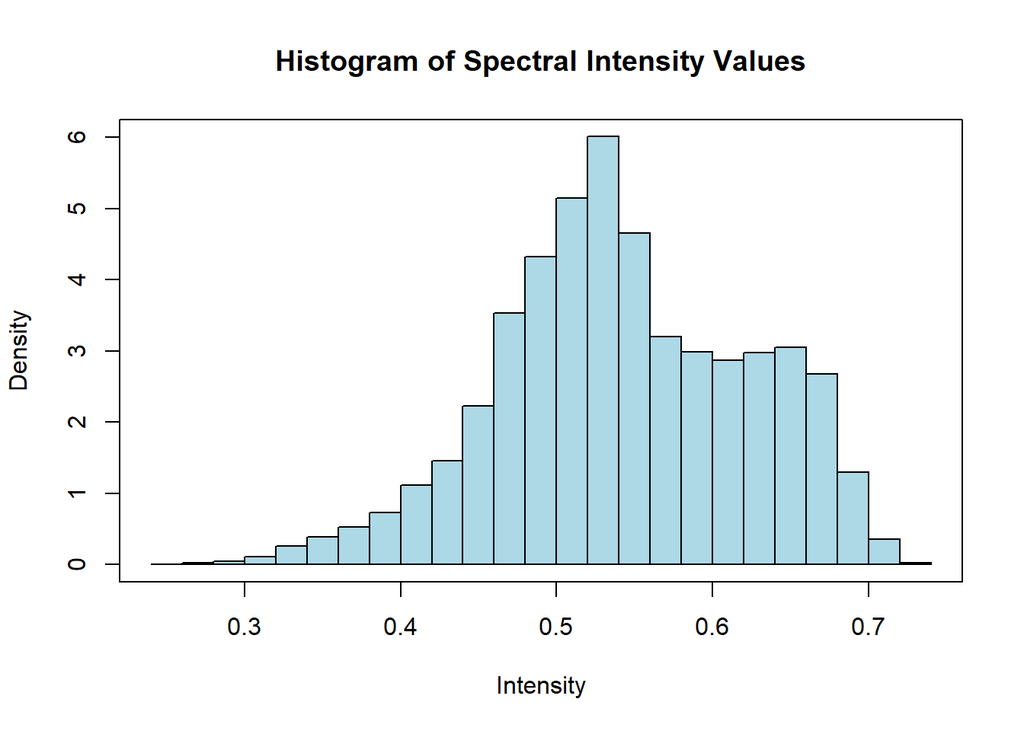

```r
hist(as.matrix(X), col = 'lightblue', freq = FALSE,
     main = 'Histogram of Spectral Intensity Values', xlab = 'Intensity'); box()
```